# Лабораторная работа №3

Markdown

Ежова А. М.

Российский университет дружбы народов, Москва, Россия

Факультет физико-математических и естесвенных наук

# Информация

## Докладчик

- Ежова Алиса Михайловна
- студентка НБИбд-01-22
- Российский университет дружбы народов
- https://github.com/AlisaEzhova

[figure not shown]

# Вводная часть

## Актуальность

- Данная работа актуальна для студентов, которые хотят освоить умения по работе с языком разметки Markdown.

## Цели и задачи

- Научиться оформлять отчёты с помощью легковесного языка разметки Markdown.

## Материалы и методы

- Процессор `pandoc` для входного формата Markdown
- Результирующие форматы
  - `pdf`
  - `html`
- Автоматизация процесса создания: `Makefile`

# Создание презентации

## Процессор `pandoc`

- Pandoc: преобразователь текстовых файлов
- Сайт: https://pandoc.org/
- Репозиторий: https://github.com/jgm/pandoc

## Формат `pdf`

- Использование LaTeX
- Пакет для презентации: beamer
- Тема оформления: `metropolis`

## Код для формата `pdf`

```yaml
slide_level: 2
aspectratio: 169
section-titles: true
theme: metropolis
```

## Формат `html`

- Используется фреймворк [reveal.js](https://revealjs.com/)
- Используется [тема](https://revealjs.com/themes/) `beige`

## Код для формата `html`

- Тема задаётся в файле `Makefile`

```
REVEALJS_THEME = beige
```

# Результаты

## Получающиеся форматы

- Полученный `pdf`-файл можно демонстрировать в любой программе просмотра `pdf`
- Полученный `html`-файл содержит в себе все ресурсы: изображения, css, скрипты

## Содержание исследования

1. Базовая настройка git:

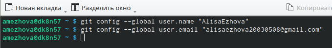

Настройка git

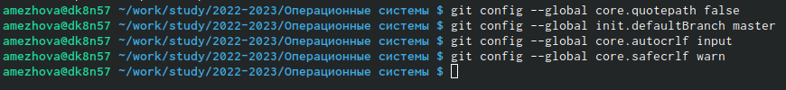

Настройка utf-8

2. Создание ключей ssh:

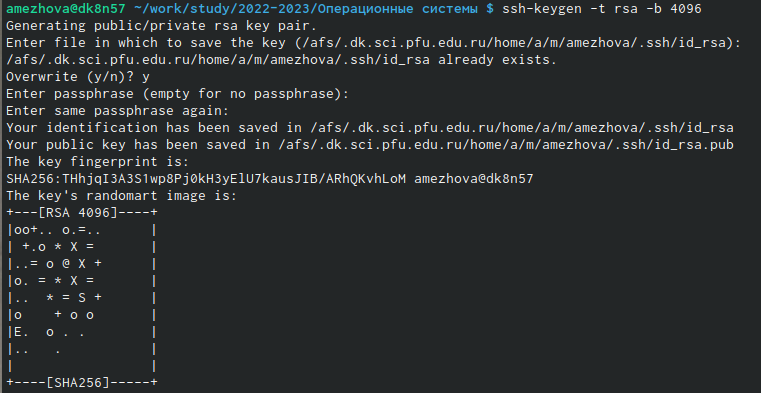

ssh ключ

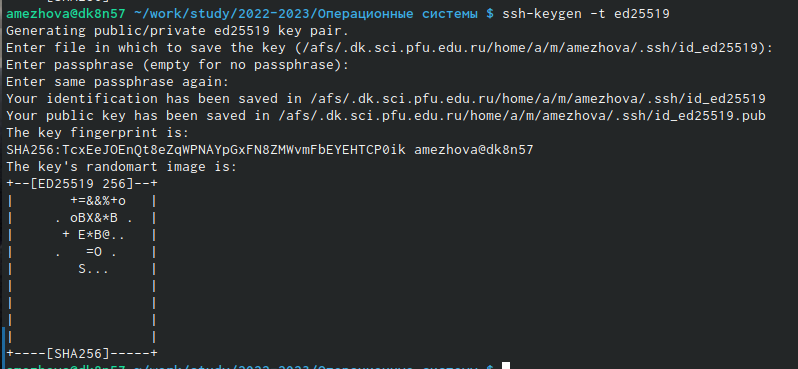

ssh ключ

3. Создание репозитория курса на основе шаблона:

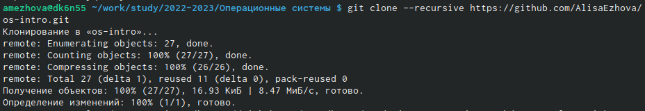

Клонирование репозитория

4. Создание pgp ключа:

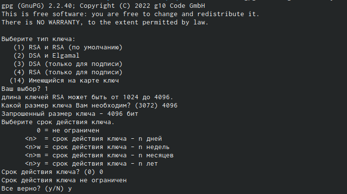

Настройка ключа

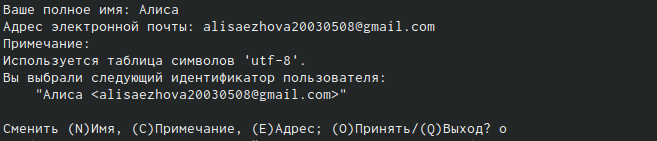

Настройка ключа

5. Добавление PGP ключа в GitHub:

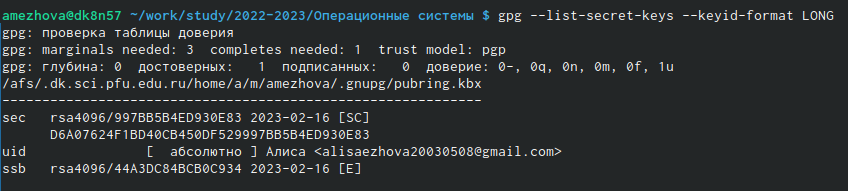

Добавление gpg ключа на GitHub

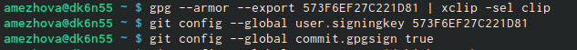

Формат gpg ключа

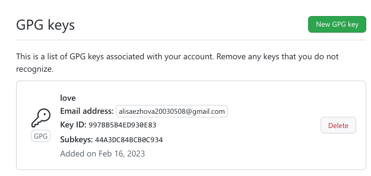

Ключ на GitHub

6. Настройка автоатических подписей коммитов git:

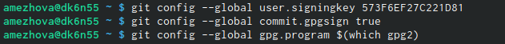

Настройка коммитов

7. Настройка каталога курса: Перейдем в каталог, удалим лишние файлы и создадим необходимые каталоги:

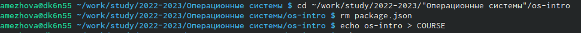

Настройка каталога

8. Отправка файлов на сервер:

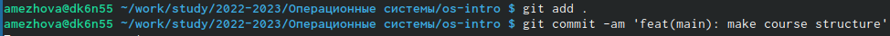

Отправка

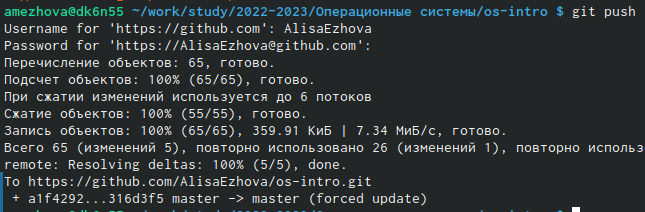

Отправка

9. Проверяем наличие папок и файлов на GitHub:

[figure not shown]

Проверка

## Результаты

- Научились работать с Markdown.
- Оформили отчеты по предыдущей лабораторной работе.

## Итоговый слайд

В ходе выполнения лабораторной работы №3, я научилась оформлять отчеты с помощью легковесного языка разметки Markdown.